# Lake Cushman Salmon Life Cycle Models, Part 2: More complex models and fitting a State Space Model

Jacob Usinowicz

2025-03-05

## Goals

1. Review the simple two-stage life cycle model
2. Add some complexity by linking population dynamics to environmental covariates.
3. Show some examples of numerical sensitivity analyses using the simulations.
4. Introduction to State Space Models (SSM) and fitting in a Bayesian framework
5. Assessing model fit

# Introduction

We present a two-stage life cycle model for salmon based on the population model presented in the paper “Development of a Two-Stage Life Cycle Model for Oncorhynchus kisutch (Coho Salmon) in the Upper Cowlitz River Basin, Washington” By John M. Plumb and Russell W. Perry. It focuses on the stock-recruitment phase and the juvenile-to-adult recruitment (JAR) stage while incorporating some additional complexity by linking population dynamics to environmental covariates. We demonstrate population dynamics over time using a simulation approach.

1. **Stock-Recruitment (Adult to Juvenile transition):** Modeled using the Ricker function.
2. **Juvenile-to-Adult Return (JAR):** A density-independent survival rate.

In addition to simulating data from the model, we further show how to fit a State Space Model (SSM) to recover the original parameters. This is meant primarily as an example of how to use RStan to define the process model, observation model, and correctly define and fit parameters. It also allows exploration into what parameters are the most difficult to capture statistically.

## Overview of Stock Recruitment Function

The stock-recruitment function describes the relationship between the number of spawning adults (stock) and the number of offspring that survive to the juvenile stage (recruits). This relationship is crucial for understanding population dynamics and managing fish stocks effectively.

One common model used in fisheries science is the **Ricker stock-recruitment model**, which accounts for density-dependent effects on reproduction. The function is given by:

$$R_J = E_F \alpha e^{-\beta E_F}$$

where:

- $R_J$ is the number of juvenile recruits,
- $E_F$ is the number of spawning adults,
- $\alpha$ is the productivity parameter, representing the maximum juvenile production per spawner in ideal conditions,
- $\beta$ is the density-dependent parameter, which reduces recruitment at high spawner densities.

The Ricker model is presented in its log-linearized form in Plumb and Perry (eq 1).

The Ricker model is only one of several possible stock-recruitment functions and incorporates particular assumption. In particular, it reflects the idea that while more spawners generally produce more offspring, competition for resources can limit recruitment at high densities. The Ricker model is usually particularly good for Sockeye populations because robust populations are often spawning-habitat-limited because they can get such large numbers of adult returns (like in Alaska).Too many adults can result in the loss of productivity at higher population densities of spawners. The fisheries management concept called maximum sustained yield (MSY) tries to exploit this by allowing fisheries to take the “surplus” spawners on their way to the river from the ocean to try to optimize recruitment and the number of fish that can be harvested.

## Simulating the Ricker Model

To better understand how the Ricker model behaves, we simulate recruitment across a range of spawner abundances.

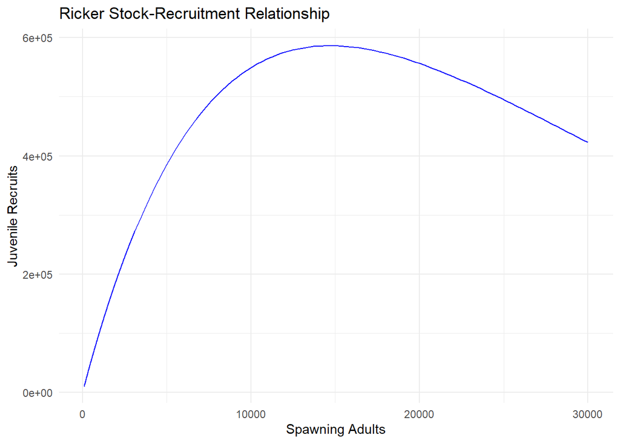

```r
# Define spawner values
E_F_vals = seq(100, 30000, length.out = 100)
alpha = 108.4
beta = 0.000068

# Compute recruitment using the Ricker model
R_J_vals = E_F_vals * alpha * exp(-beta * E_F_vals)

# Create a dataframe
df_ricker = data.frame(Spawners = E_F_vals, Recruits = R_J_vals)

# Plot the Ricker model
ricker_plot = ggplot(df_ricker, aes(x = Spawners, y = Recruits)) +
  geom_line(color = "blue") +
  labs(title = "Ricker Stock-Recruitment Relationship", x = "Spawning Adults", y = "Juvenile Recruits") +
  theme_minimal()

print(ricker_plot)
```

## Overview of Juvenile-to-Adult Recruitment Function

The second stage of the life cycle model represents the extensive environmental filter that reduces juveniles before they return and become spawners. This is often modeled as a density-independent process where a fixed proportion of juveniles survive to adulthood. The function is given by:

$$R_A = R_J \times JAR$$

where:

- $R_A$ is the number of returning adults,
- $R_J$ is the number of juveniles,
- $JAR$ is the juvenile-to-adult return rate, representing the proportion of juveniles that survive to adulthood.

This function accounts for survival rates influenced by environmental conditions, predation, and other factors affecting juvenile mortality.

## Simulating the Juvenile-to-Adult Recruitment Function

To visualize the effect of the JAR function, we simulate a range of juvenile populations and apply the return rate.

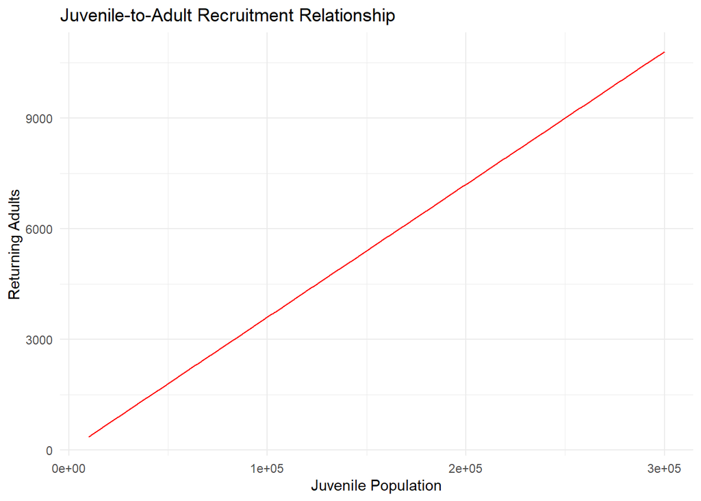

```r
# Define juvenile values
R_J_vals = seq(10000, 300000, length.out = 100)
JAR = 0.036

# Compute adult recruitment
R_A_vals = R_J_vals * JAR

# Create a dataframe
df_jar = data.frame(Juveniles = R_J_vals, Adults = R_A_vals)

# Plot the JAR function
jar_plot = ggplot(df_jar, aes(x = Juveniles, y = Adults)) +
  geom_line(color = "red") +
  labs(title = "Juvenile-to-Adult Recruitment Relationship", x = "Juvenile Population", y = "Returning Adults") +
  theme_minimal()

print(jar_plot)
```

## Two-stage model with environmental drivers

Any number of environmental factors can potentially impact the productivity of juveniles. In particular, Plumb and Perry identify the juvenile collection efficiency (FCE) and spill days as measured covariates that influence productivity.

- **FCE:** Higher values lead to improved collection of juveniles for transport.
- **Spill Days:** More spill days can negatively impact recruitment by increasing downstream losses.

To incorporate these into the model, they make they productivity parameter linearly dependent on FCE and spill days:

$$ln(\alpha_y) = \theta_0+ \theta_1 FCE + \theta_2 Sp$$

where $theta_0$ is the intercept, $theta_1$ is the slope for the effect of fish collection efficiency on productivity, and $theta_2$ is the slope for the effect of the number of days of spill (Sp) over a specified period.

To match the patterns observed in the paper, we initialize these here as follows:

```r
#Declare the FCE and Sp variables
FCE = c(rnorm(18, 0.324, 0.137), rnorm(7, 0.778, 0.094))  # Low before 2013, high after
FCE = pmax(pmin(FCE, 0.90), 0.06)  # Bound within observed range

Sp = c(rnorm(18, 17.4 - 5, 10.6), rnorm(7, 17.4 + 5, 10.6))
Sp = pmax(Sp, 0)  # No negative spill days
```

### Model Setup and Parameters

This section initializes parameters for the simulation. These parameters influence how the model incorporates productivity, density dependence, fish collection efficiency (FCE), and spill effects.They are already familiar from the descriptions above.

```r
# Set seed for reproducibility
set.seed(42)

# Simulation parameters from posterior distributions
n_years = 25
theta_0 = log(108.4)  # Mean productivity at FCE = 1
theta_1 = 3.501  # Strong positive effect of FCE on productivity
theta_2 = -0.3  # Spill effect (estimate retained)
beta = 0.000068  # Median capacity parameter
sigma_pJ = 0.3
sigma_pA = 0.2
JAR = 0.036  # Median juvenile-to-adult return rate
sigma_RJ0 = 0.5
sigma_RA0 = 0.3

# Generate years
years = 1995:(1995 + n_years - 1)
```

### Running the Full Model Simulation

```r
# Initialize vectors
R_J = numeric(n_years)  # Juveniles
R_A = numeric(n_years)  # Adults

# Initial conditions
R_J[1:2] = exp(rnorm(2, log(118729), sigma_RJ0))  # Mean 118,729, SD 87,881
R_A[1:2] = exp(rnorm(2, log(5000), sigma_RA0))  # Rough approximation

# Simulate population process
for (y in 2:(n_years-1)) {

  # Productivity with environmental covariates: alpha is linked to FCE and Spill
  alpha_y = exp(theta_0 + theta_1 * FCE[y] + theta_2 * Sp[y])

  R_J[y+1] = exp(log(R_A[y]) + log(alpha_y) - beta *  R_A [y] + rnorm(1, 0, sigma_pJ))
  R_A[y+1] = exp(log(R_J[y]) + log(JAR) + rnorm(1, 0, sigma_pA))
}
```

## Visualization of Population Trends

We plot the simulated juvenile and adult populations over time to observe trends.

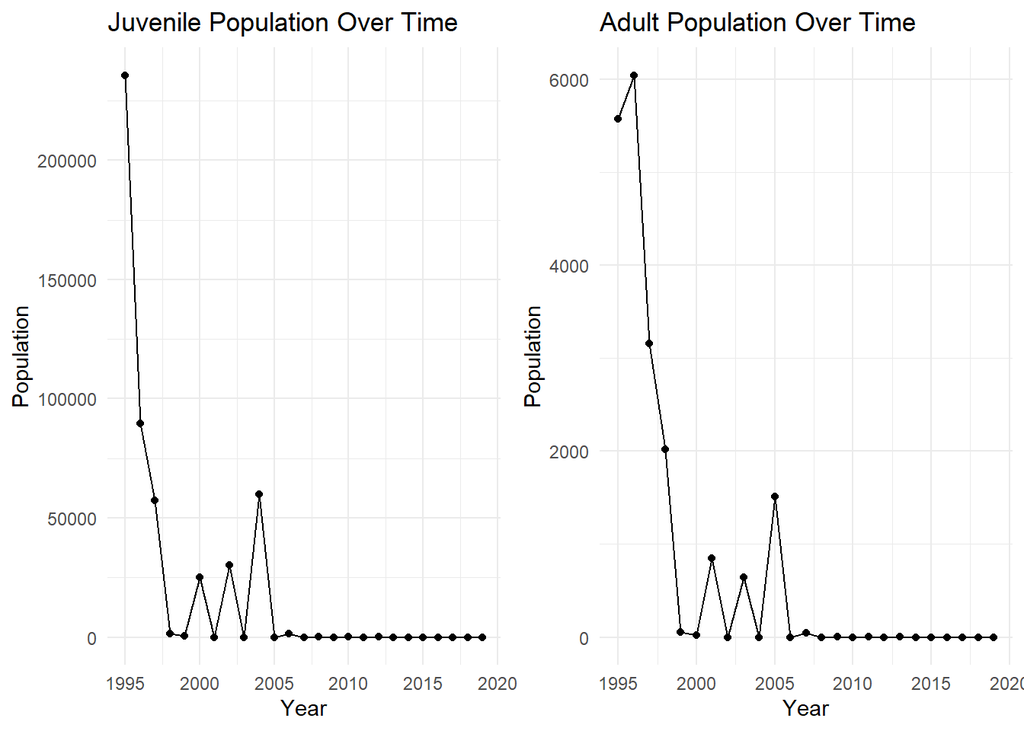

```r
df_obs = data.frame(Year = years, Juveniles = R_J, Adults = R_A)


p1 = ggplot(df_obs, aes(x = Year, y = Juveniles)) +
  geom_point() +
  geom_line() +
  labs(title = "Juvenile Population Over Time", x = "Year", y = "Population") +
  theme_minimal()

p2 = ggplot(df_obs, aes(x = Year, y = Adults)) +
  geom_point() +
  geom_line() +
  labs(title = "Adult Population Over Time", x = "Year", y = "Population") +
  theme_minimal()

grid.arrange(p1, p2, nrow = 1)
```

## Initial impressions.

This simulation incorporates the impact of key environmental factors, particularly FCE and spill days, on coho production rates and shows the dynamics expected from reported values. As is apparent from the figures above, linking these data in the way that we have makes population persistence much more challenging. Below, we make a quick investigation of the model behavior by exploring its sensitivity to some of the new parameters.

### Effect of Spill Days on Population

Spill days negatively impact juvenile production rates. Here we can investigate a range of values to see where the population becomes stable again.

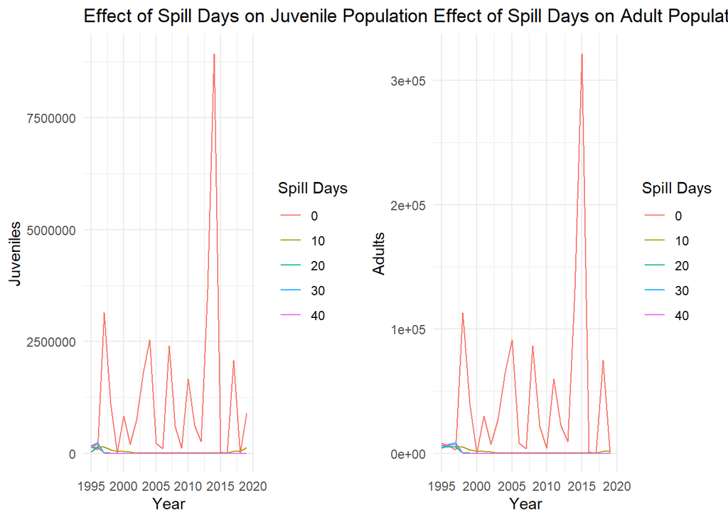

```r
# Define spill day variations
spill_values = seq(0, 40, by = 10)

# Store results
spill_results = data.frame(Spill = rep(spill_values, each = n_years),
                           Year = rep(years, times = length(spill_values)),
                           Juveniles = NA, Adults = NA)

# Run simulation for different spill values
for (i in seq_along(spill_values)) {
  Sp_sim = spill_values[i]
  R_J_sim = numeric(n_years)
  R_A_sim = numeric(n_years)

  # Initial conditions
  R_J_sim[1:2] = exp(rnorm(2, log(118729), sigma_RJ0))  # Mean 118,729, SD 87,881
  R_A_sim[1:2] = exp(rnorm(2, log(5000), sigma_RA0))  # Rough approximation

  for (y in 2:(n_years-1)) {
    alpha_y_sim = exp(theta_0 + theta_1 * FCE[y] + theta_2 * Sp_sim)
    R_J_sim[y+1] = exp(log(R_A_sim[y]) + log(alpha_y_sim) - beta * R_A_sim[y])
    R_A_sim[y+1] = exp(log(R_J_sim[y]) + log(JAR))

  }

  spill_results$Juveniles[spill_results$Spill == Sp_sim] = R_J_sim
  spill_results$Adults[spill_results$Spill == Sp_sim] = R_A_sim
}

# Plot results
p1 = ggplot(spill_results, aes(x = Year, y = Juveniles, color = factor(Spill))) +
  geom_line() +
  labs(title = "Effect of Spill Days on Juvenile Population",
       x = "Year", y = "Juveniles", color = "Spill Days") +
  theme_minimal()

p2 = ggplot(spill_results, aes(x = Year, y = Adults, color = factor(Spill))) +
  geom_line() +
  labs(title = "Effect of Spill Days on Adult Population",
       x = "Year", y = "Adults", color = "Spill Days") +
  theme_minimal()

grid.arrange(p1, p2, nrow = 1)
```

### Sensitivity Analysis of Fish Collection Efficiency

Fish collection efficiency (FCE) is another important factor influencing the rate of juvenile production.

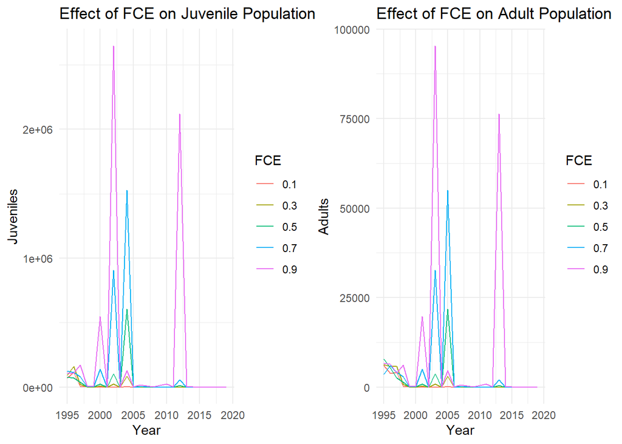

```r
# Define FCE variations
FCE_values = seq(0.1, 0.9, by = 0.2)

# Store results
FCE_results = data.frame(FCE = rep(FCE_values, each = n_years),
                         Year = rep(years, times = length(FCE_values)),
                         Juveniles = NA, Adults = NA)

# Run simulation for different FCE values
for (i in seq_along(FCE_values)) {
  FCE_sim = FCE_values[i]
  R_J_sim = numeric(n_years)
  R_A_sim = numeric(n_years)

  # Initial conditions
  R_J_sim[1:2] = exp(rnorm(2, log(118729), sigma_RJ0))  # Mean 118,729, SD 87,881
  R_A_sim[1:2] = exp(rnorm(2, log(5000), sigma_RA0))  # Rough approximation

  for (y in 2:(n_years-1)) {
    alpha_y_sim = exp(theta_0 + theta_1 * FCE_sim + theta_2 * Sp[y])
    R_J_sim[y+1] = exp(log(R_A_sim[y]) + log(alpha_y_sim) - beta * R_A_sim[y])
    R_A_sim[y+1] = exp(log(R_J_sim[y]) + log(JAR))
  }

  FCE_results$Juveniles[FCE_results$FCE == FCE_sim] = R_J_sim
  FCE_results$Adults[FCE_results$FCE == FCE_sim] = R_A_sim
}

# Plot results
p1= ggplot(FCE_results, aes(x = Year, y = Juveniles, color = factor(FCE))) +
  geom_line() +
  labs(title = "Effect of FCE on Juvenile Population",
       x = "Year", y = "Juveniles", color = "FCE") +
  theme_minimal()

p2 = ggplot(FCE_results, aes(x = Year, y = Adults, color = factor(FCE))) +
  geom_line() +
  labs(title = "Effect of FCE on Adult Population",
       x = "Year", y = "Adults", color = "FCE") +
  theme_minimal()

grid.arrange(p1, p2, nrow = 1)
```

### Effect of Juvenile-to-Adult Return Rate

Since JAR influences how many juveniles return as adults, we explore different return rates.

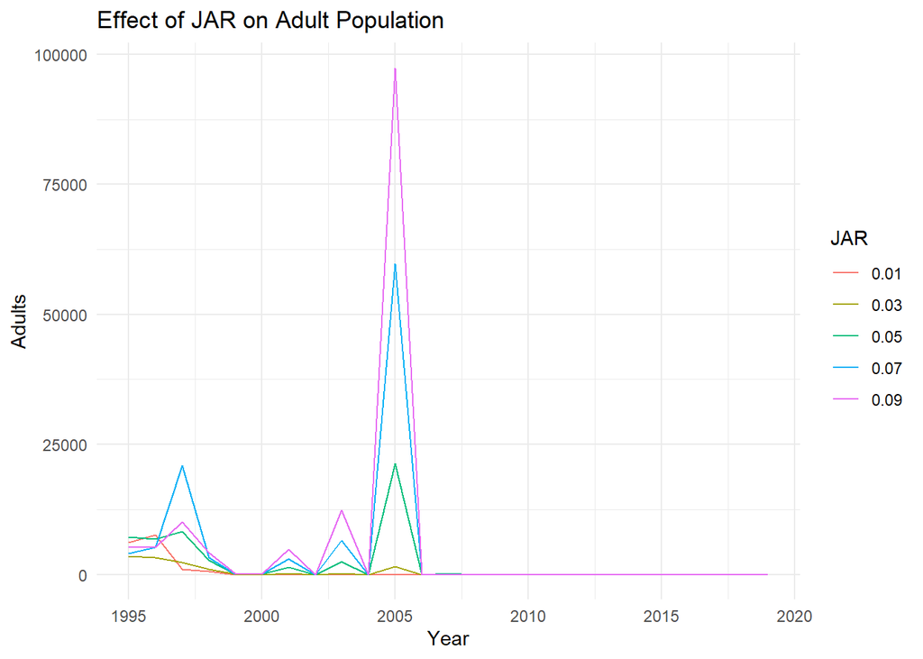

```r
# Define JAR variations
JAR_values = seq(0.01, 0.10, by = 0.02)

# Store results
JAR_results = data.frame(JAR = rep(JAR_values, each = n_years),
                         Year = rep(years, times = length(JAR_values)),
                         Juveniles = NA, Adults = NA)

# Run simulation for different JAR values
for (i in seq_along(JAR_values)) {
  JAR_sim = JAR_values[i]
  R_J_sim = numeric(n_years)
  R_A_sim = numeric(n_years)

  # Initial conditions
  R_J_sim[1:2] = exp(rnorm(2, log(118729), sigma_RJ0))  # Mean 118,729, SD 87,881
  R_A_sim[1:2] = exp(rnorm(2, log(5000), sigma_RA0))  # Rough approximation

  for (y in 2:(n_years-1)) {
    alpha_y_sim = exp(theta_0 + theta_1 * FCE[y] + theta_2 * Sp[y])
    R_J_sim[y+1] = exp(log(R_A_sim[y]) + log(alpha_y_sim) - beta * R_A_sim[y])
    R_A_sim[y+1] = exp(log(R_J_sim[y]) + log(JAR_sim))
  }

  JAR_results$Juveniles[JAR_results$JAR == JAR_sim] = R_J_sim
  JAR_results$Adults[JAR_results$JAR == JAR_sim] = R_A_sim
}

# Plot results
ggplot(JAR_results, aes(x = Year, y = Adults, color = factor(JAR))) +
  geom_line() +
  labs(title = "Effect of JAR on Adult Population",
       x = "Year", y = "Adults", color = "JAR") +
  theme_minimal()
```

## Conclusions from the model

One of the biggest contributors to stabilizing coho population dynamics under this formulation are the number of spill days, an important point also discussed by Plumb and Perry. Fewer spill days improve return rates. FCE and JAR also predictibly improve return rates, but also have a substantial impact on the variance in the dynamics. An interesting next step would be to explore the *relative* impact of each of these terms on populations, e.g. by measuring in terms of per-capita increases not absolute changes in the population size.

# Introduction to State Space Models

In this section, we will explore how to fit a state-space model (SSM) to salmon population data. SSMs are a versatile tool for modeling dynamic systems that change over time, especially when there are uncertainties in both the process generating the data and the measurement of that data.

An SSM generally consists of two key components:

**Process Model**: This describes how the true (latent) states evolve over time. In our case, this is the population model, which captures how the salmon population grows, decreases, or changes over time, based on biological factors like survival rates and environmental conditions.

**Observation Model**: This describes how we measure or observe these latent states, often with some amount of noise or error. Here, we use a statistical model to capture the discrepancy between the true population state and what we actually observe (for example, data on the number of salmon counted, which may not be exact due to measurement issues like fish count errors).

SSMs are particularly powerful because they allow us to account for both process uncertainty (how the population evolves over time) and measurement error (how accurately we observe the population). In the context of salmon population dynamics, an SSM helps us estimate the relationships between various factors like escapement, juvenile survival, and adult returns while considering environmental influences, such as spill days and fish collection efficiency (FCE).

By using SSMs, we can improve our understanding of complex systems where both the underlying processes and the data are uncertain. While a more detailed theoretical discussion can be found elsewhere, our goal here is to show you how to fit an SSM to simulated salmon population data using RStan, a powerful tool for Bayesian modeling.

### Aside: Bayesian approaches to model fitting

Fitting state-space models (SSMs) can be done using either a frequentist or Bayesian framework, each with its own strengths. Frequentist approaches, often based on maximum likelihood estimation, are typically faster and may be more familiar to many researchers. However, Bayesian methods offer greater flexibility, particularly in incorporating prior information and interpreting uncertainty. Instead of relying on single-point estimates and p-values, Bayesian inference provides full probability distributions for model parameters, allowing for a more nuanced understanding of uncertainty.

A key difference between the two approaches is how uncertainty is quantified. Frequentist confidence intervals express the range in which a parameter would fall in repeated samples, but they do not provide a probability statement about the parameter itself. In contrast, Bayesian credible intervals offer a direct probability interpretation. This distinction is especially useful in SSMs, where we estimate hidden states (such as population size over time) and wish to assess the credibility of those estimates. Bayesian methods use Markov Chain Monte Carlo (MCMC) techniques to approximate posterior distributions, allowing for robust inference even when data are sparse or noisy.

Another advantage of Bayesian inference is its ability to incorporate prior knowledge, such as expert opinion or information from previous studies, which can be particularly beneficial in ecological modeling. While frequentist methods treat parameters as fixed but unknown quantities, Bayesian methods continuously update our beliefs as new data become available. This makes them well-suited for complex models like SSMs, where latent states evolve dynamically over time. Below is an R code example comparing frequentist and Bayesian estimation of a simple parameter.

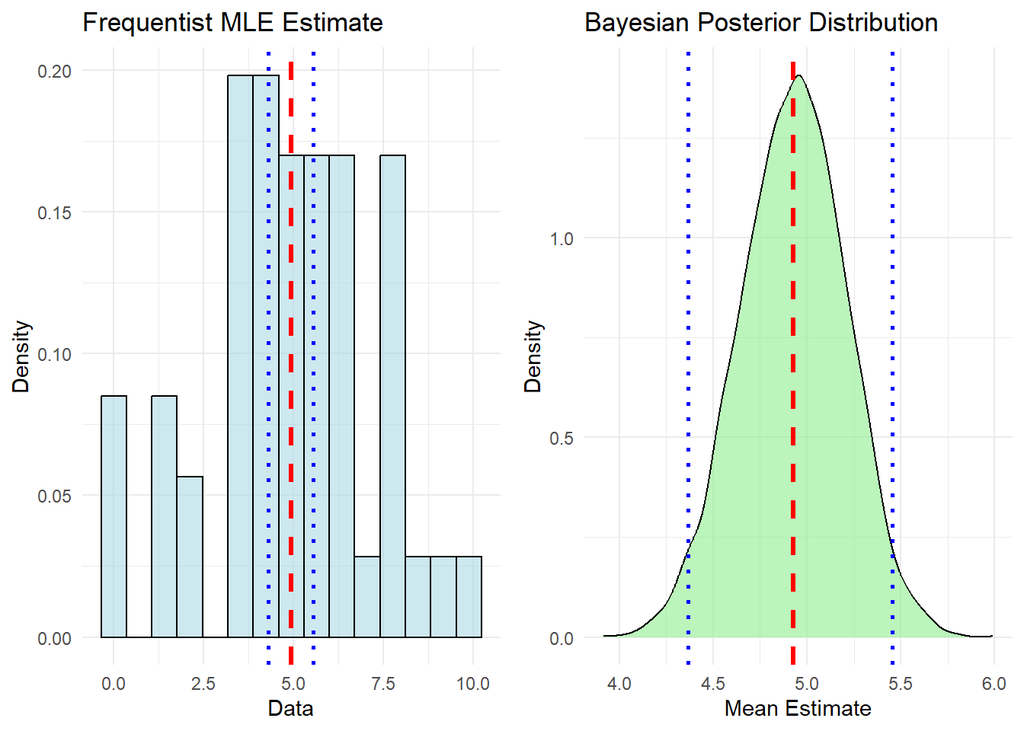

```r
# Simulate some data
set.seed(42)
data = rnorm(50, mean = 5, sd = 2)

# Frequentist approach: Maximum Likelihood Estimation (MLE)
mle_fit = fitdistr(data, "normal")

# Extract MLE estimate and confidence interval
mle_mean = mle_fit$estimate["mean"]
mle_ci = confint(mle_fit)  # Matrix with confidence bounds

# Ensure correct indexing
mle_lower = mle_ci[1, 1]  # Lower bound of mean CI
mle_upper = mle_ci[1, 2]  # Upper bound of mean CI

# Bayesian approach using Stan
stan_code = "
  data {
    int<lower=0> N;
    real y[N];
  }
  parameters {
    real mu;
  }
  model {
    mu ~ normal(0, 10);  // Prior
    y ~ normal(mu, 2);   // Likelihood
  }
"
# Fit Bayesian model
stan_data = list(N = length(data), y = data)
fit = stan(model_code = stan_code, data = stan_data, iter = 2000, chains = 4, cores = 4, refresh = 0)

# Extract Bayesian estimates
posterior_samples = extract(fit)$mu
bayes_mean = mean(posterior_samples)
bayes_ci = quantile(posterior_samples, probs = c(0.025, 0.975))

# Plot Frequentist MLE
p1 = ggplot(data.frame(data), aes(x = data)) +
  geom_histogram(aes(y = ..density..), bins = 15, fill = "lightblue", color = "black", alpha = 0.6) +
  geom_vline(xintercept = mle_mean, color = "red", linetype = "dashed", size = 1.2) +
  geom_vline(xintercept = mle_lower, color = "blue", linetype = "dotted", size = 1) +
  geom_vline(xintercept = mle_upper, color = "blue", linetype = "dotted", size = 1) +
  labs(title = "Frequentist MLE Estimate", x = "Data", y = "Density") +
  theme_minimal()

# Plot Bayesian posterior distribution
p2 = ggplot(data.frame(mu = posterior_samples), aes(x = mu)) +
  geom_density(fill = "lightgreen", alpha = 0.6) +
  geom_vline(xintercept = bayes_mean, color = "red", linetype = "dashed", size = 1.2, label = "Posterior Mean") +
  geom_vline(xintercept = bayes_ci[1], color = "blue", linetype = "dotted", size = 1) +
  geom_vline(xintercept = bayes_ci[2], color = "blue", linetype = "dotted", size = 1) +
  labs(title = "Bayesian Posterior Distribution", x = "Mean Estimate", y = "Density") +
  theme_minimal()

grid.arrange(p1, p2, nrow = 1)
```

Frequentist Histogram:

- The histogram represents the observed data distribution.
- The red dashed line is the MLE estimate for the mean.
- The blue dotted lines indicate the 95% confidence interval.

Bayesian Posterior Distribution:

- The density plot shows the posterior distribution of the mean.
- The red dashed line is the posterior mean estimate.
- The blue dotted lines represent the 95% credible interval.

The frequentist method provides a point estimate and confidence interval, while the Bayesian approach provides an entire distribution, allowing for more nuanced uncertainty interpretation.

## Data Preparation

First, we’re going to re-run the simulation using the insights we gained during our sensitivity analysis to get better data.

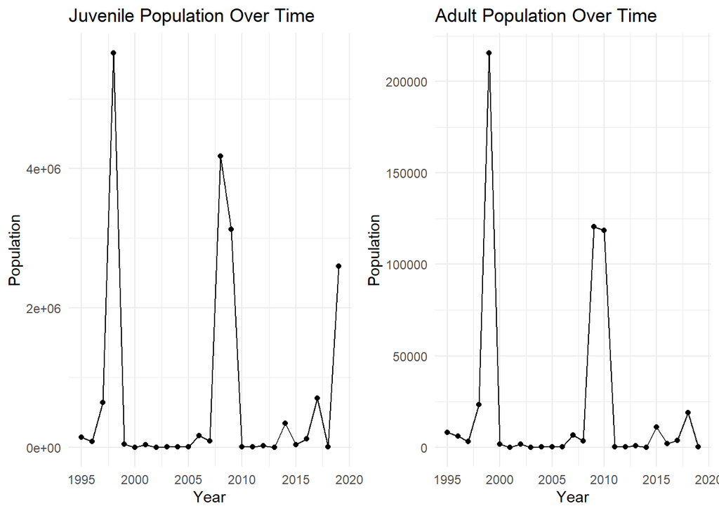

```r
# Set seed for reproducibility
set.seed(42)

# Simulation parameters from posterior distributions
n_years = 25
theta_0 = log(108.4)  # Mean productivity at FCE = 1
theta_1 = 3.501  # Strong positive effect of FCE on productivity
theta_2 = -0.3  # Spill effect (estimate retained)
beta = 0.000068  # Median capacity parameter
sigma_pJ = 0.3
sigma_pA = 0.2
JAR = 0.036  # Median juvenile-to-adult return rate
sigma_RJ0 = 0.5
sigma_RA0 = 0.3

# Generate years
years = 1995:(1995 + n_years - 1)

#Declare the FCE and Sp variables
FCE = c( rnorm(n_years, 0.778, 0.094))  # Make higher across all years
FCE = pmax(pmin(FCE, 0.90), 0.06)  # Bound within observed range

Sp = c( rnorm(n_years, 10, 10.6)) #Low spill days are better
Sp = pmax(Sp, 0)  # No negative spill days

# Initialize vectors
R_J = numeric(n_years)  # Juveniles
R_A = numeric(n_years)  # Adults

# Initial conditions
R_J[1:2] = exp(rnorm(2, log(118729), sigma_RJ0))  # Mean 118,729, SD 87,881
R_A[1:2] = exp(rnorm(2, log(5000), sigma_RA0))  # Rough approximation

# Simulate population process
for (y in 2:(n_years-1)) {

  # Productivity with environmental covariates
  alpha_y = exp(theta_0 + theta_1 * FCE[y] + theta_2 * Sp[y])
  R_J[y+1] = exp(log(R_A[y]) + log(alpha_y) - beta *  R_A [y] + rnorm(1, 0, sigma_pJ))
  R_A[y+1] = exp(log(R_J[y]) + log(JAR) + rnorm(1, 0, sigma_pA))
}

df_obs = data.frame(Year = years, Juveniles = R_J, Adults = R_A)
p1 = ggplot(df_obs, aes(x = Year, y = Juveniles)) +
  geom_point() +
  geom_line() +
  labs(title = "Juvenile Population Over Time", x = "Year", y = "Population") +
  theme_minimal()

p2 = ggplot(df_obs, aes(x = Year, y = Adults)) +
  geom_point() +
  geom_line() +
  labs(title = "Adult Population Over Time", x = "Year", y = "Population") +
  theme_minimal()

grid.arrange(p1, p2, nrow = 1)
```

With the new data, we can first log-transform the observed juvenile and adult counts to stabilize variance and ensure normality.

```r
log_RJ = log(R_J)
log_RA = log(R_A)
Y = cbind(log_RJ, log_RA)  # Combine into a matrix
```

## Define the Stan Model

The model describes the process and observation components: - **Process model:** Defines the latent state dynamics of juvenile and adult recruits. - **Observation model:** Links observed data to latent states, incorporating observation error.

```r
stan_code = "
data {
  int<lower=1> n_years;       // Number of years
  vector[n_years] FCE;      // Fish collection efficiency
  vector[n_years] Sp;       // Spill days
  matrix[n_years, 2] Y;       // Log-transformed observed recruits
}

parameters {
  real theta_0;
  real theta_1;
  real theta_2;
  real<lower=0> beta;
  real<lower=0> JAR;
  real<lower=0> sigma_pJ;
  real<lower=0> sigma_pA;
  vector[n_years] log_RJ;
  vector[n_years] log_RA;
}

model {
  // Uninformed priors
  theta_0 ~ normal(0, 5);
  theta_1 ~ normal(0, 5);
  theta_2 ~ normal(0, 5);
  beta ~ uniform(0, 1);
  JAR ~ uniform(0, 1);
  sigma_pJ ~ exponential(1);
  sigma_pA ~ exponential(1);

  // Process model
  for (y in 2:(n_years-1)) {
    real alpha_y = exp(theta_0 + theta_1 * FCE[y] + theta_2 * Sp[y]);
    log_RJ[y+1] ~ normal(log_RA[y] + log(alpha_y) - beta * exp(log_RA[y]), sigma_pJ);
    log_RA[y+1] ~ normal(log_RJ[y] + log(JAR), sigma_pA);
  }

  // Observation model
  for (y in 1:n_years) {
    Y[y, 1] ~ normal(log_RJ[y], sigma_pJ);
    Y[y, 2] ~ normal(log_RA[y], sigma_pA);
  }
}
"
```

### Explanation of Stan Code

**Parameters Block**: Specifies model parameters, including population productivity (theta_0), environmental effects (theta_1, theta_2), density dependence (beta), and transition rates (JAR). Process errors (sigma_pJ, sigma_pA) account for biological variation.

# Model Fitting

Prepare the data and run the model.Running the fit can take some time.

```r
stan_data = list(
  n_years = n_years,
  FCE = FCE,
  Sp = Sp,
  Y = Y
)

fit = stan(model_code = stan_code, data = stan_data, iter = 2000, chains = 4, cores = 4)

#Get the posterior samples and predictions for analysis
posterior_samples = extract(fit)
log_RJ_pred = apply(posterior_samples$log_RJ, 2, median)
log_RA_pred = apply(posterior_samples$log_RA, 2, median)
```

# Model Results and Diagnostics

## Plots of actual vs. predicted populations

It’s always nice to plot the predictions made by the fitted model against the actual data. This will give us our first visual indication of whether we’ve captured the underlying dynamics.

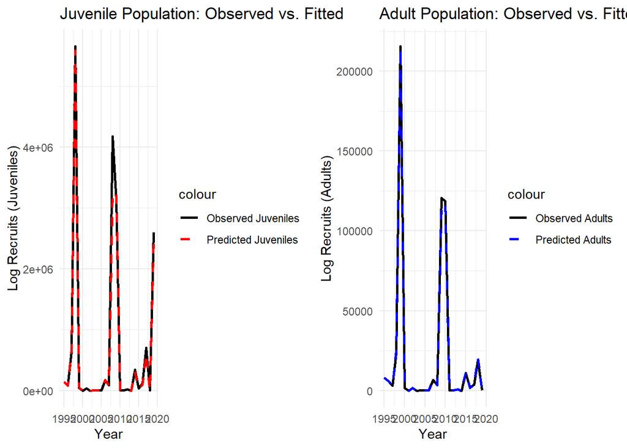

```r
# Create a dataframe for plotting
plot_data <- data.frame(
  Year = years,
  Observed_J = (R_J),
  Observed_A = (R_A),
  Predicted_J = exp(log_RJ_pred),
  Predicted_A = exp(log_RA_pred)
)

# Plot Juvenile predictions vs. observed
p1 = ggplot(plot_data, aes(x = Year)) +
  geom_line(aes(y = Observed_J, color = "Observed Juveniles"), size = 1) +
  geom_line(aes(y = Predicted_J, color = "Predicted Juveniles"), size = 1, linetype = "dashed") +
  labs(title = "Juvenile Population: Observed vs. Fitted",
       y = "Log Recruits (Juveniles)", x = "Year") +
  scale_color_manual(values = c("Observed Juveniles" = "black", "Predicted Juveniles" = "red")) +
  theme_minimal()

# Plot Adult predictions vs. observed
p2 = ggplot(plot_data, aes(x = Year)) +
  geom_line(aes(y = Observed_A, color = "Observed Adults"), size = 1) +
  geom_line(aes(y = Predicted_A, color = "Predicted Adults"), size = 1, linetype = "dashed") +
  labs(title = "Adult Population: Observed vs. Fitted",
       y = "Log Recruits (Adults)", x = "Year") +
  scale_color_manual(values = c("Observed Adults" = "black", "Predicted Adults" = "blue")) +
  theme_minimal()

grid.arrange(p1, p2, nrow = 1)
```

## Simulated vs. Estimated Parameters

Take a look at the fitted and the actual parameters side by side in a table:

```r
params = data.frame(
  Parameter = c("theta_0", "theta_1", "theta_2", "beta", "JAR"),
  Simulated = c(log(theta_0), theta_1, theta_2, beta, JAR),
  Estimated = c(median(posterior_samples$theta_0), median(posterior_samples$theta_1),
                median(posterior_samples$theta_2), median(posterior_samples$beta),
                median(posterior_samples$JAR))
)

knitr::kable(params)
```

[output not shown]

Plotted:

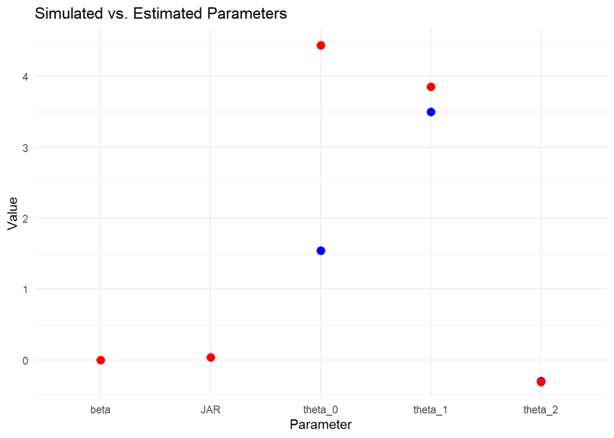

```r
ggplot(params, aes(x = Parameter, y = Simulated)) +
  geom_point(color = "blue", size = 3) +
  geom_point(aes(y = Estimated), color = "red", size = 3) +
  geom_line(aes(y = Simulated, group = Parameter), color = "blue", linetype = "dashed") +
  geom_line(aes(y = Estimated, group = Parameter), color = "red") +
  labs(title = "Simulated vs. Estimated Parameters", y = "Value") +
  theme_minimal()
```

## Observed vs. Predicted Values

One useful way to quickly look at the performance of the model is to plot the predicted vs. actual values, plot the 1-to-1 line, and see how well points match to this line.

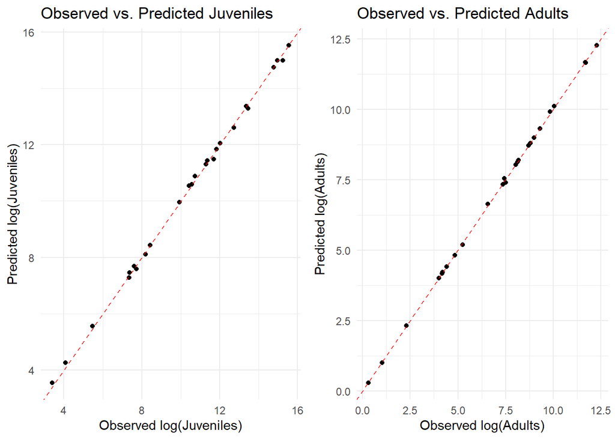

```r
df_obs_pred = data.frame(
  Year = years,
  Observed_J = Y[, 1],
  Predicted_J = log_RJ_pred,
  Observed_A = Y[, 2],
  Predicted_A = log_RA_pred
)

p1=ggplot(df_obs_pred, aes(x = Observed_J, y = Predicted_J)) +
  geom_point() +
  geom_abline(slope = 1, intercept = 0, linetype = "dashed", color = "red") +
  labs(title = "Observed vs. Predicted Juveniles", x = "Observed log(Juveniles)", y = "Predicted log(Juveniles)") +
  theme_minimal()

p2=ggplot(df_obs_pred, aes(x = Observed_A, y = Predicted_A)) +
  geom_point() +
  geom_abline(slope = 1, intercept = 0, linetype = "dashed", color = "red") +
  labs(title = "Observed vs. Predicted Adults", x = "Observed log(Adults)", y = "Predicted log(Adults)") +
  theme_minimal()

grid.arrange(p1, p2, nrow = 1)
```

# Residual Analysis

Just like in frequentist approaches, we can look at the residuals and visually inspect their dispersion. Any remaining clustering or trends would be indicative of sources of variation that we have not accounted for.

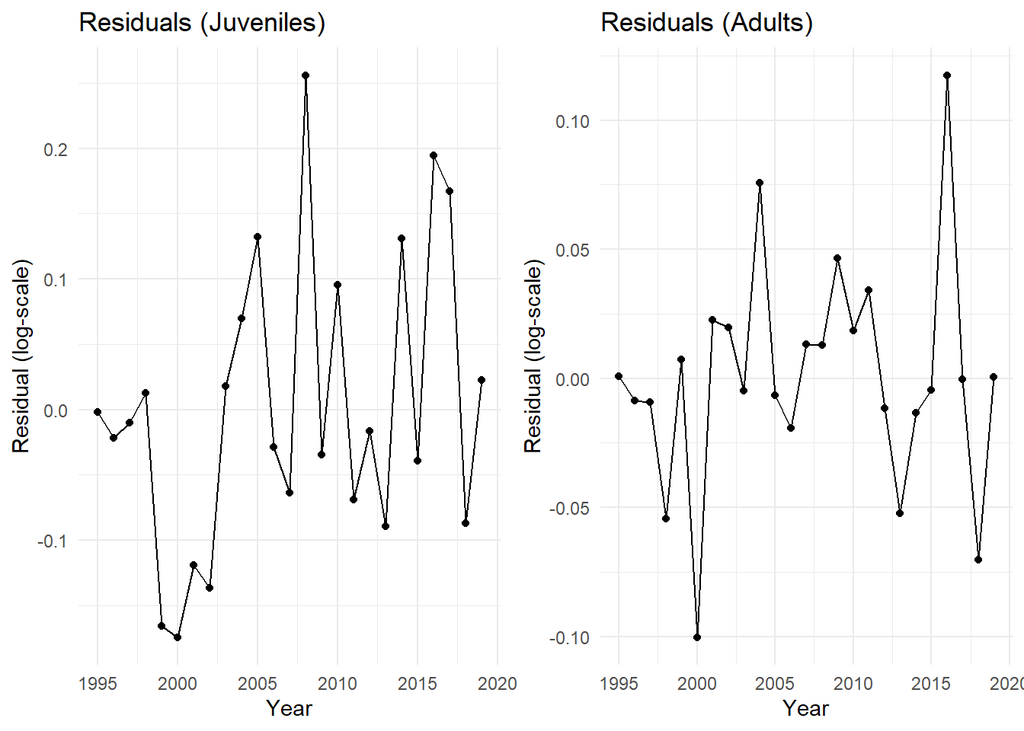

```r
df_residuals = data.frame(
  Year = years,
  Residual_J = Y[, 1] - log_RJ_pred,
  Residual_A = Y[, 2] - log_RA_pred
)

p1 = ggplot(df_residuals, aes(x = Year, y = Residual_J)) +
  geom_line() + geom_point() +
  labs(title = "Residuals (Juveniles)", x = "Year", y = "Residual (log-scale)") +
  theme_minimal()

p2 = ggplot(df_residuals, aes(x = Year, y = Residual_A)) +
  geom_line() + geom_point() +
  labs(title = "Residuals (Adults)", x = "Year", y = "Residual (log-scale)") +
  theme_minimal()

grid.arrange(p1, p2, nrow = 1)
```

# Conclusion

This analysis demonstrates the application of a state-space model to salmon population data, highlighting latent state estimation and observation uncertainty. Further refinements can be explored by adjusting priors and model structure.